# 📊🌍🐍 Explorando Colombia a través de los datos geoespaciales con GeoPandas en Python 🐍🌍📊

```python
import matplotlib.pyplot as plt
import matplotlib.image as mpimg
```

[figure not shown]

```python
imagen_ruta = "Geopandas.jpg"
img = mpimg.imread(imagen_ruta)
plt.figure(figsize=(18, 10))
plt.imshow(img)
plt.axis('off')
plt.show()
```

- Autor: **Juan Miguel Rodríguez Trujillo**
- Fecha: **Febrero de 2025**

## Importar librerías

Importamos las librerías necesarias para realizar el análisis: `pandas`, `geopandas` y `matplotlib`

```python
import pandas as pd
import geopandas as gpd
import matplotlib.pyplot as plt


from matplotlib.lines import Line2D
from matplotlib.patches import Patch
```

## Cargar archivos .xlsx con información de las variables socioeconómicas para Colombia

Cargamos archivos .xlsx con la librería `pandas`

### 1. Índice de pobreza multidimensional (IPM)

```python
ruta_archivo_IPM = "IPM (Porcentaje).xlsx"
df_ipm = pd.read_excel(ruta_archivo_IPM)
```

### 2. Población con estudios de pregrado o superiores

```python
ruta_archivo_universitarios = "Universitarios.xlsx"
df_universitarios = pd.read_excel(ruta_archivo_universitarios)
```

### 3. PIB per cápita

```python
ruta_archivo_PIB = "PIB_per_cápita.xlsx"
df_PIB = pd.read_excel(ruta_archivo_PIB)
```

### 4. Tasa de desempleo

```python
ruta_archivo_desempleo = "desempleo.xlsx"
df_desempleo = pd.read_excel(ruta_archivo_desempleo)
```

### 5. Índice de competitividad (IDC)

```python
ruta_archivo_IDC = "IDC.xlsx"
df_IDC = pd.read_excel(ruta_archivo_IDC)
```

## Estandarizar nombres de los elementos de la columna "DEPARTAMENTOS"

**Es fundamental homogenizar los nombres de los elementos de la columna identificadora `"DEAPARTAMENTOS"` para posteriormente realizar el merge**. En este caso los estandarizamos usando mayúsculas y eliminando espacios extra innecesarios en la escritura. Este proceso se realiza para todos los datasets.

```python
df_ipm['DEPARTAMENTO'] = df_ipm['DEPARTAMENTO'].str.upper().str.strip()
df_universitarios['DEPARTAMENTO'] = df_universitarios['DEPARTAMENTO'].str.upper().str.strip()
df_PIB['DEPARTAMENTO'] = df_PIB['DEPARTAMENTO'].str.upper().str.strip()
df_desempleo['DEPARTAMENTO'] = df_desempleo['DEPARTAMENTO'].str.upper().str.strip()
df_IDC['DEPARTAMENTO'] = df_IDC['DEPARTAMENTO'].str.upper().str.strip()
```

## Cargar archivo .shapefile con información geográfica de los departamentos de Colombia

**Un archivo Shapefile es un formato estándar utilizado en los Sistemas de Información Geográfica (SIG) para almacenar datos geoespaciales vectoriales.** Un Shapefile puede representar puntos, líneas o polígonos para mapear ubicaciones geográficas como ciudades, ríos o límites políticos.

Aunque se le llama "archivo Shapefile", en realidad está compuesto por varios archivos que trabajan juntos, siendo los principales:

- shp — Contiene las geometrías (formas) de los objetos geográficos.
- shx — Es un índice que facilita el acceso a los datos.
- dbf — Almacena los atributos asociados (datos tabulares) de cada objeto geográfico.

**Para cargar el archivo .shapefile hacemos uso de `geopandas`.** Esto permite interpretar los elementos de las variables del archivo .shapefile como coordenadas y límites geográficos.

**El DANE proporciona para Colombia el archivo .shapefile de libre acceso**

```python
shapefile_colombia_ruta = "MGN2023_DPTO_POLITICO"
colombia_mapa = gpd.read_file(shapefile_colombia_ruta)
```

### Gráfico del mapa base para Colombia

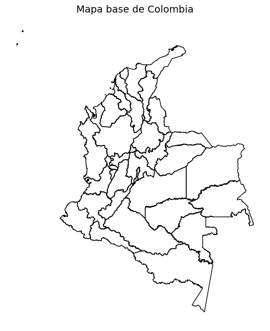

```python
colombia_mapa.plot(figsize=(10, 8), edgecolor='black', facecolor='none')
plt.title('Mapa base de Colombia', fontsize=14)
plt.axis('off')  # Opcional para eliminar los ejes
plt.show()
```

### Estandarizar elementos de variable identificadora para el .shapefile

En esta parte estandarizamos los nombres de los departamentos. Añadimos mayúscula sostenida y eliminamos espacios innecesarios en su escritura con las funciones `.str.upper()` y `.str.strip()`, respectivamente.

También modificamos los nombres de algunos departamentos para que coincidan con los `df_xxxx`. Este se logra con la función `.replace`.

Finalmente, renombramos la columna `'dpto_cnombr'` y la nombramos `'DEPARTAMENTO'`. Esto con la función `.rename`.

```python
colombia_mapa["dpto_cnmbr"] = colombia_mapa["dpto_cnmbr"].str.upper().str.strip()

colombia_mapa['dpto_cnmbr'] = colombia_mapa['dpto_cnmbr'].replace({
    'QUINDIO': 'QUINDÍO',
    'BOGOTÁ, D.C.': 'BOGOTÁ D.C.',
    'ARCHIPIÉLAGO DE SAN ANDRÉS, PROVIDENCIA Y SANTA CATALINA': 'SAN ANDRÉS'
})

colombia_mapa.rename(columns={'dpto_cnmbr': 'DEPARTAMENTO'}, inplace=True)
```

## Índice de Pobreza Multidimensional (IPM)

**La medición de la pobreza se hace tradicionalmente de forma directa e indirecta, siguiendo la clasificación de Amartya Sen.** El método directo evalúa los resultados de satisfacción (o no privación) que tiene un individuo respecto a ciertas características que se consideran vitales como salud, educación, empleo, entre otras. Una de las principales métricas directas de evaluación de la pobreza es el Índice de Pobreza Multidimensional (IPM).

### Merge

En este caso usamos datos de la **Encuesta Nacional de Calidad de Vida (ECV) - 2023** realizada por el **DANE**. Luego, realizamos el **merge de datasets**: `colombia_mapa`, que contiene información geográfica de Colombia, y `df_ipm`, que contiene información sobre el IPM, generando el nuevo dataset `colombia_ipm`.

```python
colombia_ipm = colombia_mapa.merge(df_ipm, on='DEPARTAMENTO', how='left')
```

### Gráfico

Realizamos el gráfico con información de la columna `IPM (Porcentaje)`, del dataset `colombia_ipm`.

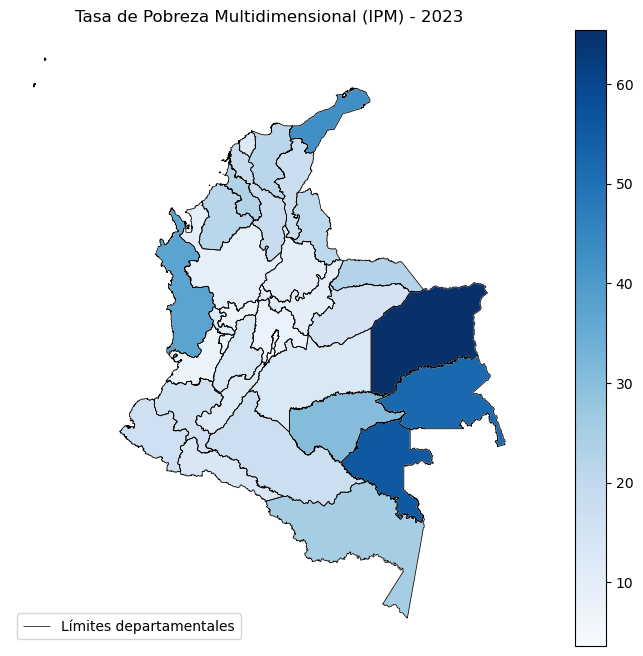

```python
fig, ax = plt.subplots(1, 1, figsize=(12, 8))

colombia_ipm.plot(column='IPM (Porcentaje)', cmap='Blues', linewidth=0.8, ax=ax, edgecolor='0.8', legend=True, missing_kwds={
    "color": "lightgrey",
    "edgecolor": "red",
    "hatch": "///",
    "label": "Sin datos"
})
colombia_ipm.boundary.plot(ax=ax, color='black', linewidth=0.5, label='Límites departamentales')

ax.legend(loc='lower left')
ax.set_title('Tasa de Pobreza Multidimensional (IPM) - 2023')
ax.axis('off')

plt.show()
```

## Población con estudios universitarios de pregrado

**Jacob Mincer demostró que la educación tiene un impacto directo y positivo en los ingresos laborales mediante su famosa Ecuación de Mincer.** Este modelo muestra que los ingresos aumentan con cada año adicional de escolaridad y experiencia laboral, destacando el valor económico de invertir en capital humano.

La ecuación de Mincer se expresa como: $$ \ln(Y) = \beta_0 + \beta_1 S + \beta_2 X + \beta_3 X^2 + \epsilon $$

Donde:

$\begin{align} Y & : \text{Ingresos laborales} \\ S & : \text{Años de escolaridad} \\ X & : \text{Años de experiencia laboral} \\ X^2 & : \text{Experiencia laboral al cuadrado (efectos decrecientes)} \\ \beta_0 & : \text{Término constante} \\ \beta_1, \beta_2, \beta_3 & : \text{Coeficientes a estimar} \\ \epsilon & : \text{Término de error} \end{align}$

### Merge

En este caso usamos datos del **Censo Nacional de Población y Vivienda (CNPV) - 2018** realizado por el **DANE**. Luego, realizamos el **merge de datasets**: `colombia_mapa`, que contiene información geográfica de Colombia, y `df_universitarios`, que contiene información sobre los estudios de la población colombiana, generando el nuevo dataset `colombia_universitarios`.

```python
colombia_universitarios = colombia_mapa.merge(df_universitarios, on='DEPARTAMENTO', how='left')
```

### Gráfico

Realizamos el gráfico con información de la columna `Universitarios`, del dataset `colombia_universitarios`.

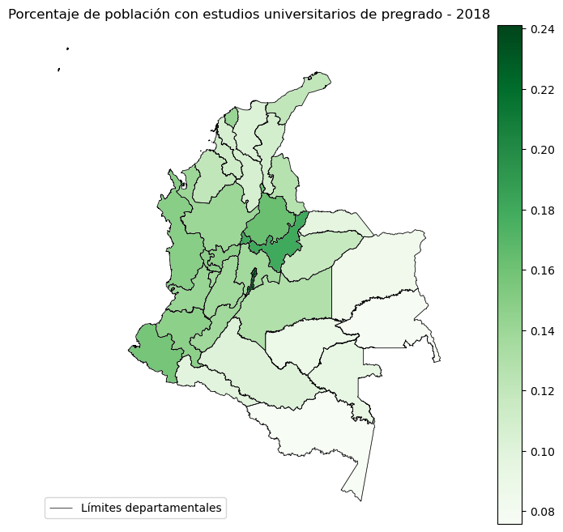

```python
fig, ax = plt.subplots(1, 1, figsize=(12, 8))

colombia_universitarios.plot(column='Universitarios', cmap='Greens', linewidth=0.8, ax=ax, edgecolor='0.8', legend=True, missing_kwds={
    "color": "lightgrey",
    "edgecolor": "red",
    "hatch": "///",
    "label": "Sin datos"
})

colombia_universitarios.boundary.plot(ax=ax, color='black', linewidth=0.5, label='Límites departamentales')
ax.legend(loc='lower left')
ax.set_title('Porcentaje de población con estudios universitarios de pregrado - 2018')
ax.axis('off')

plt.show()
```

# PIB per cápita

**El PIB per cápita es un indicador económico que mide el Producto Interno Bruto (PIB) de un territorio dividido entre su población total.** Representa el promedio de producción económica por persona en un periodo determinado, generalmente un año. Aunque no refleja directamente la distribución del ingreso ni las desigualdades sociales, se utiliza comúnmente como una medida aproximada del nivel de bienestar y el desarrollo económico de un territorio.

$$ \text{PIB per cápita} = \frac{\text{PIB}}{\text{Población total}} $$

### Merge

En este caso usamos datos del **PIB total departamental (2023)**, calculado por el **DANE**. Luego, realizamos el **merge de datasets**: `colombia_mapa`, que contiene información geográfica de Colombia, y `df_PIB`, que contiene información sobre el valor del PIB departamental, generando el nuevo dataset `colombia_PIB`.

```python
colombia_PIB = colombia_mapa.merge(df_PIB, on='DEPARTAMENTO', how='left')
```

### Gráfico

Realizamos el gráfico con información de la columna `PIB per cápita`, del dataset `colombia_PIB`.

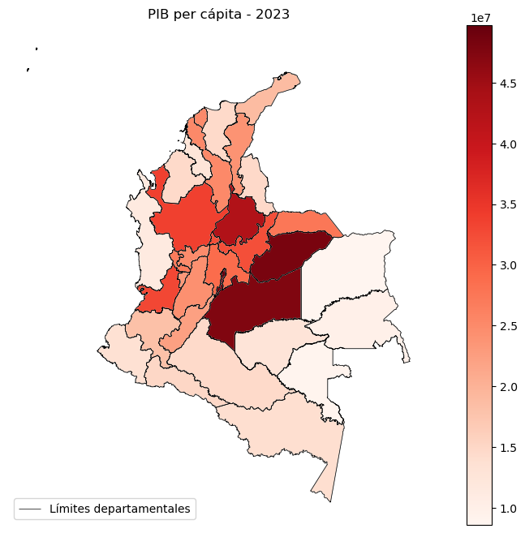

```python
fig, ax = plt.subplots(1, 1, figsize=(12, 8))

colombia_PIB.plot(column='PIB per cápita', cmap='Reds', linewidth=0.8, ax=ax, edgecolor='0.8', legend=True, missing_kwds={
    "color": "lightgrey",
    "edgecolor": "red",
    "hatch": "///",
    "label": "Sin datos"
})

colombia_PIB.boundary.plot(ax=ax, color='black', linewidth=0.5, label='Límites departamentales')
ax.legend(loc='lower left')
ax.set_title('PIB per cápita - 2023')
ax.axis('off')

plt.show()
```

# Tasa de Desempleo

**La tasa de desempleo (o desocupación) es uno de los principales indicadores del mercado laboral.** En Colombia es calculada por el DANE con la siguiente fórmula:

$$ TD = \frac{DS}{FT} \times 100 $$

$Donde:$

$ \begin{align} \text{TD}: \text{Tasa de desempleo} \\ \text{DS}: \text{Población desempleada} \\ \text{FT}: \text{Fuerza de trabajo} \\ \end{align} $

$ \text{De acuerdo al DANE:}$

- $DS$ corresponde a las personas de 15 años y más que durante el período de referencia estuvieron simultáneamente: "sin empleo", es decir, que no tenían un empleo asalariado o un trabajo independiente ni se desempeñaron como trabajador(a) familiar sin remuneración; "buscando empleo", es decir que habían tomado medidas concretas para buscar un empleo asalariado o independiente en las últimas 4 semanas; y "actualmente disponibles para trabajar", es decir, disponibles para trabajar en empleo asalariado o en empleo independiente durante el período de referencia.
- $FT$ comprende a las personas en edad de trabajar que trabajan o están buscando trabajo y están disponibles. Se divide en población ocupada y desocupada.

### Merge

En este caso usamos datos de la **Gran Encuesta Integrada de Hogares (GEIH) - 2023**, realizada por el **DANE**. Luego, realizamos el **merge de datasets**: `colombia_mapa`, que contiene información geográfica de Colombia, y `df_desempleo`, que contiene información sobre la tasa de desempleo, generando el nuevo dataset `colombia_desempleo`.

```python
colombia_desempleo = colombia_mapa.merge(df_desempleo, on='DEPARTAMENTO', how='left')
```

### Gráfico

Realizamos el gráfico con información de la columna `Desempleo`, del dataset `colombia_desempleo`.

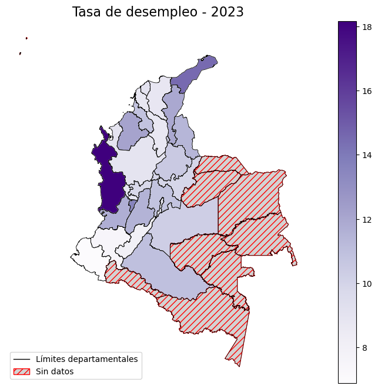

```python
fig, ax = plt.subplots(1, 1, figsize=(12, 8))

colombia_desempleo.plot(column='Desempleo', cmap='Purples', linewidth=0.8, ax=ax, edgecolor='0.8', legend=True, missing_kwds={
    "color": "lightgrey",
    "edgecolor": "red",
    "hatch": "///",
    "label": "Sin datos"
})

colombia_desempleo.boundary.plot(ax=ax, color='black', linewidth=0.5)

legend_elements = [
    Line2D([0], [0], color='black', lw=1, label='Límites departamentales'),
    Patch(facecolor='lightgrey', edgecolor='red', hatch='///', label='Sin datos')
]

ax.legend(handles=legend_elements, loc='lower left')
ax.set_title('Tasa de desempleo - 2023', fontsize=16)
ax.axis('off')
plt.show()
```

# Índice de Competitividad Departamental (IDC)

**El Índice de Competitividad Departamental (IDC) mide la capacidad de una región o país para generar bienestar económico y social sostenible, evaluando factores como educación, infraestructura, entorno empresarial e innovación.** Desarrollado en Colombia por el **Consejo Privado de Competitividad (CPC)**, este índice refleja qué tan atractivo es un territorio para la inversión y el crecimiento económico.

### Merge

```python
colombia_IDC = colombia_mapa.merge(df_IDC, on='DEPARTAMENTO', how='left')
```

### Gráfico

Realizamos el gráfico con información de la columna `IDC`, del dataset `colombia_IDC`.

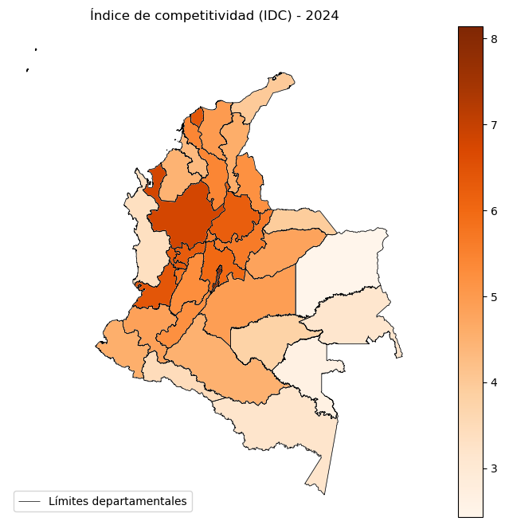

```python
fig, ax = plt.subplots(1, 1, figsize=(12, 8))

colombia_IDC.plot(column='IDC', cmap='Oranges', linewidth=0.8, ax=ax, edgecolor='0.8', legend=True, missing_kwds={
    "color": "lightgrey",
    "edgecolor": "red",
    "hatch": "///",
    "label": "Sin datos"
})

colombia_ipm.boundary.plot(ax=ax, color='black', linewidth=0.5, label='Límites departamentales')
ax.legend(loc='lower left')
ax.set_title('Índice de competitividad (IDC) - 2024')
ax.axis('off')

plt.show()
```

# Bono: GeoPandas para el Mapamundi

Como bono, también se instruirá en **cómo usar geopandas en un Mapamundi**. Para esto, se usará el archivo `.shapefile` disponible en la página **Natural Earth**, que nos proporcionará información geográfica de los límites político-administrativos internacionales.

#### Shapefile de Natural Earth

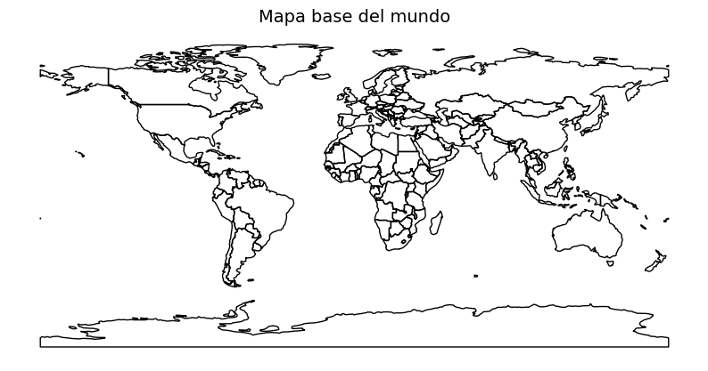

```python
# Ruta al archivo .shapefile descargado de Natural Earth
shapefile_path_world = "admin_countries"

# Cargar el Shapefile con GeoPandas
world = gpd.read_file(shapefile_path_world)

# Estandarizar los nombres de los países en el Shapefile (mayúsculas y sin espacios extra)
world["ADMIN"] = world["ADMIN"].str.upper().str.strip()

# Generar Mapa base del mundo
world.plot(figsize=(10, 8), edgecolor='black', facecolor='none')
plt.title('Mapa base del mundo', fontsize=14)
plt.axis('off')
plt.show()
```

#### Dataset del World Bank

```python
# Cargar datos del Banco Mundial sobre el índice GINI
ruta_archivo_GINI = "GINI.xlsx"
df_GINI = pd.read_excel(ruta_archivo_GINI)

# Estandarizar los nombres de los países en el dataset del GINI (mayúsculas y sin espacios extra)
df_GINI['ADMIN'] = df_GINI['ADMIN'].str.upper().str.strip()

# Realizar el merge
world_GINI = world.merge(df_GINI, on='ADMIN', how='left')
```

### Definición del Índice de GINI

Formalmente se puede representar como:

$$ IG = \frac{\sum_{i=1}^{k-1} (p_i - q_i)}{\sum_{i=1}^{k-1} p_i} $$

$ \text {Donde:}$

$ \begin{aligned} IG & : \ \text{Índice de Gini} \\ p_i & : \ \text{Proporción de individuos con ingresos menores a una cantidad determinada} \\ q_i & : \ \text{Porcentaje de ingresos acumulado sobre el total de los ingresos de la población} \\ i & = 1, 2, \dots, k : \ \text{Conjunto de individuos o grupos poblacionales analizados} \\ k & : \ \text{Número total de individuos o grupos considerados} \end{aligned} $

#### Gráfico

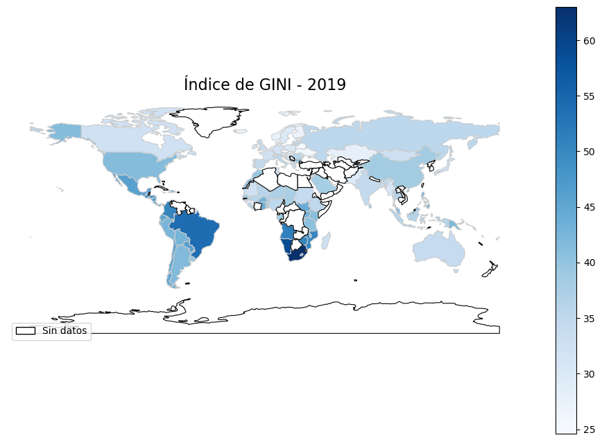

```python
# Realizar gráfico a partir del DataSet creado "world_GINI"

fig, ax = plt.subplots(1, 1, figsize=(12, 8))

world_GINI.plot(column='GINI', cmap='Blues', linewidth=0.8, ax=ax, edgecolor='0.8', legend=True, missing_kwds={
    "color": "white",
    "edgecolor": "black"
})

legend_elements = [
    Patch(facecolor='white', edgecolor='black', label='Sin datos')]


ax.legend(handles=legend_elements, loc='lower left')
ax.set_title('Índice de GINI - 2019', fontsize=16)
ax.axis('off')

plt.show()
```